# POLUIDOR INDIRETO

Análise da utilização do conceito na jurisprudência do TJSP e do STJ

Amuny Zoghbi

João Pedro Rodrigues

Luiza Ortega

Natalia Prates

Pedro Zuffo

22-06-2021

## Introdução

Apresentação dos resultados da pesquisa desenvolvida para o Projeto Multidisciplinar em ESG, ministrados pelos professores José Garcez Ghirardi e Viviane Prado na FGV DIREITO SP.

- **Objetivo:** Compreender a figura do poluidor indireto na jursiprudência do STJ e do TJSP
- **Objeto de análise:** 134 decisões entre acórdãos e monocráticas
- **Procedimento:** Leitura das decisões e tabelação das variaveis para posterior análise quantitativa e qualitativa, via programação.

## Recorte de pesquisa: decisões que foram consideradas na análise

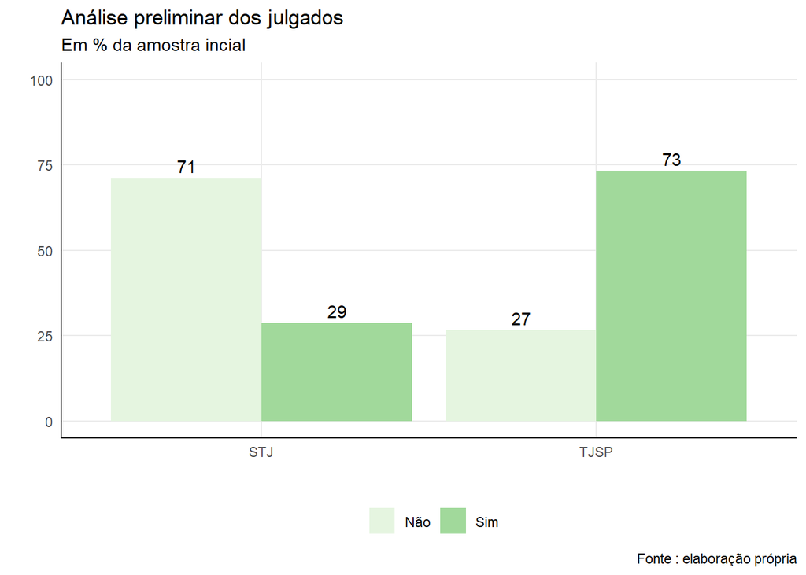

## Distribuição dos Julgados ao longo dos anos

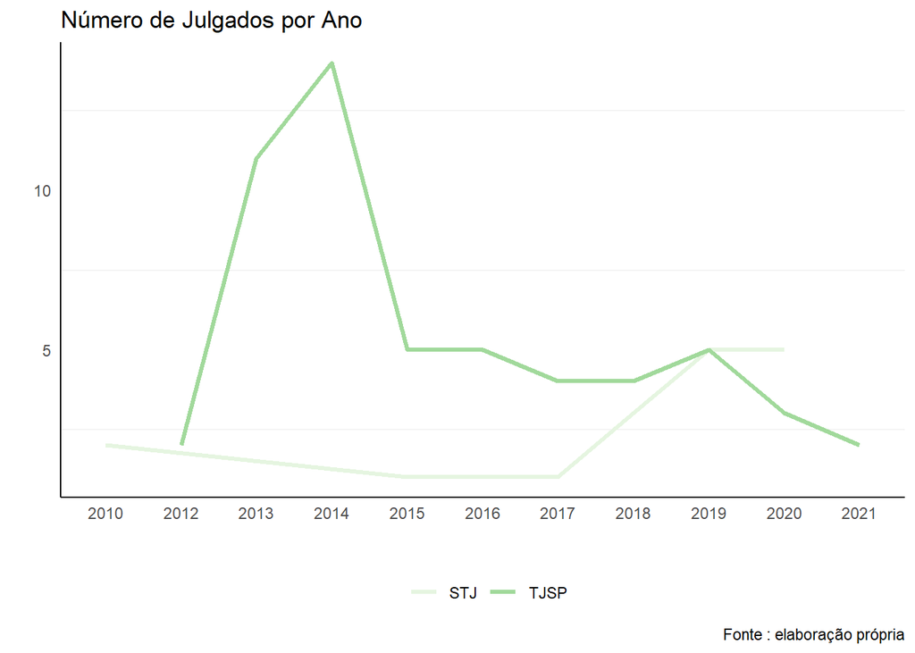

## Como os magistrados definem o conceito “poluidor indireto”?

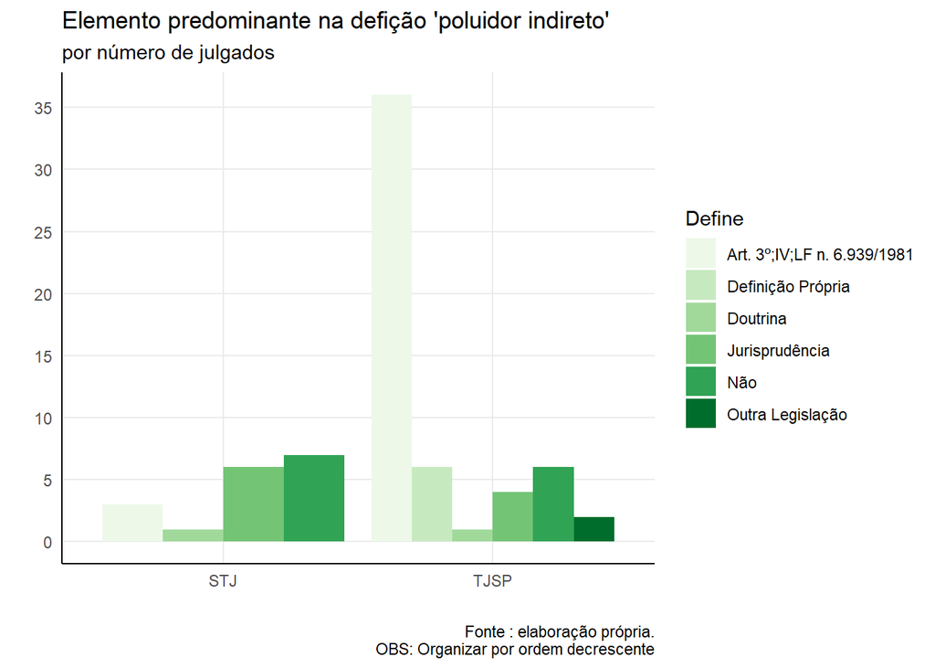

## Distribuição de julgados por órgão julgador no TJSP

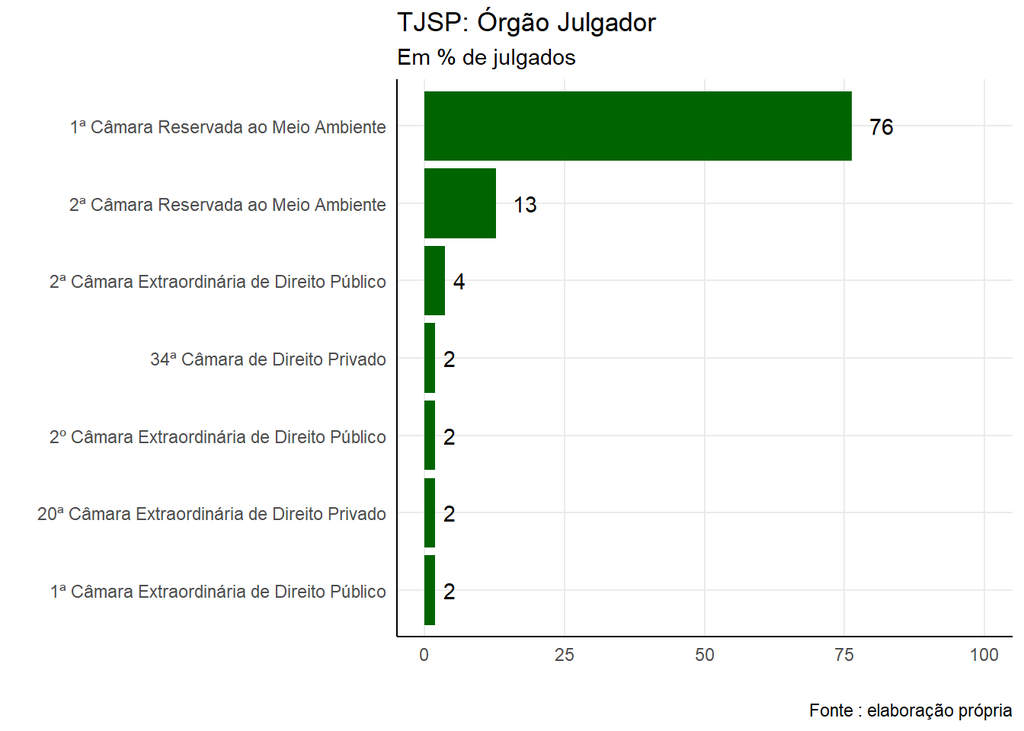

## Distribuição de julgados no STJ por Estado de origem

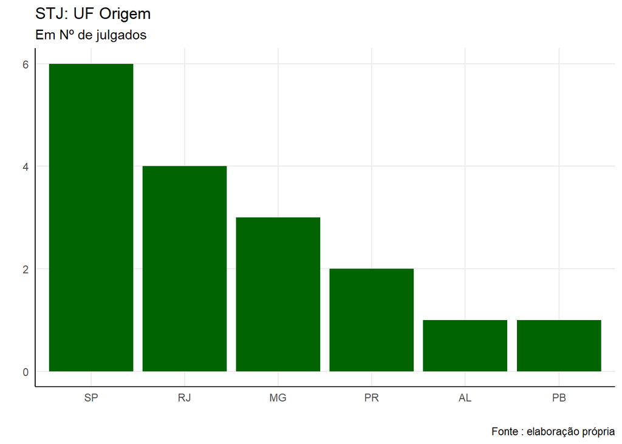

## Quem é o Poluidor Indireto?

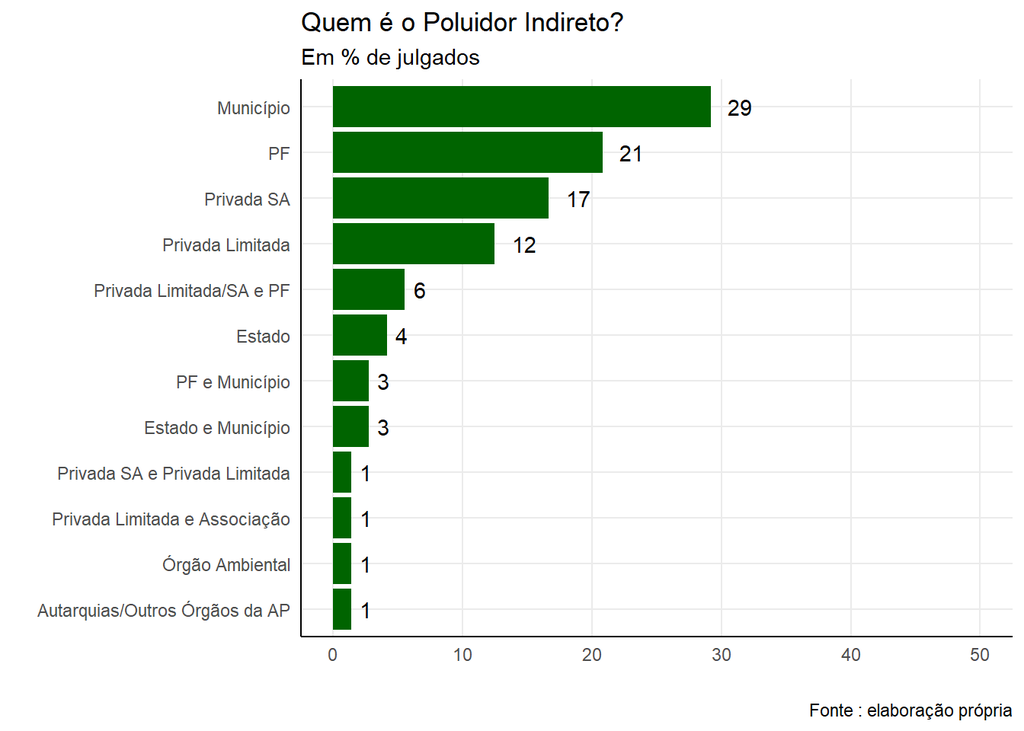

## Poluidor indireto: Publico X Privado

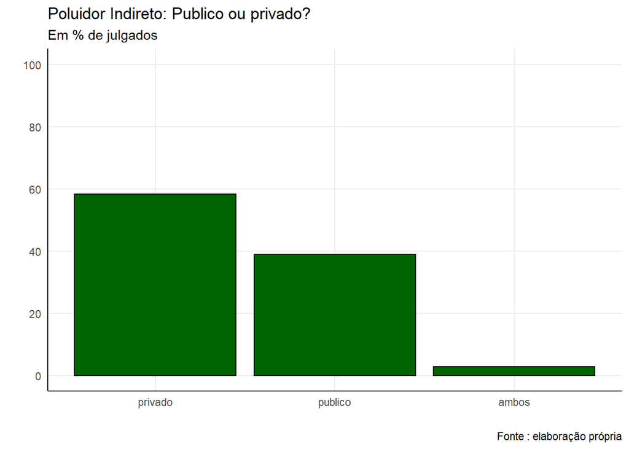

## Poluidor indireto: Pessoa Física X Pessoa Jurídica

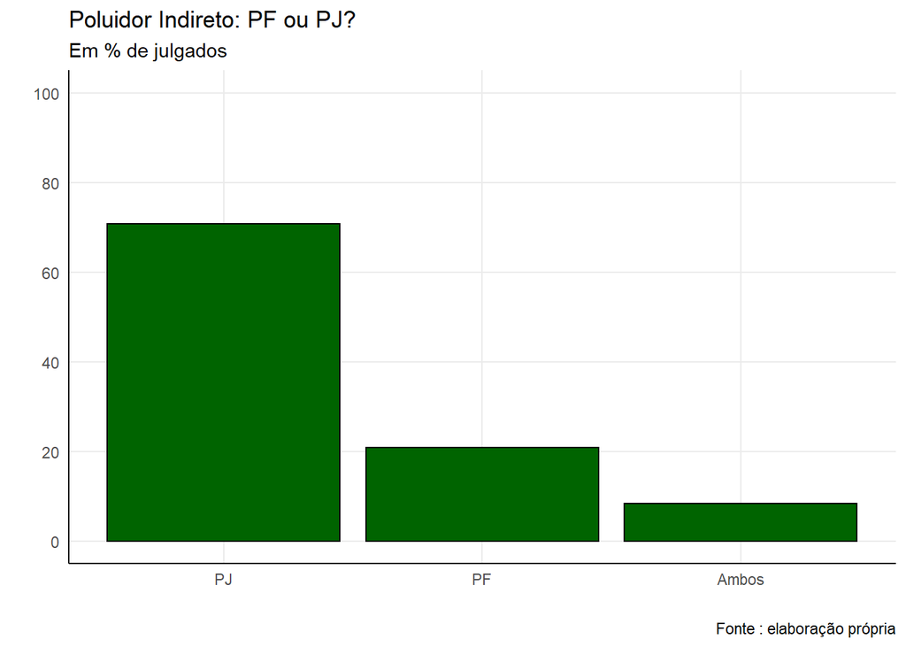

## O Poluidor Indireto é responsabilizado?

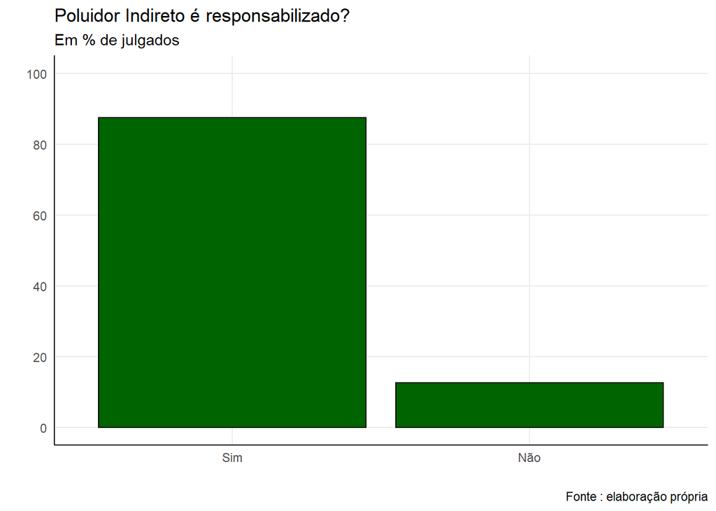

## Como o Poluidor Indireto é responsabilizado?

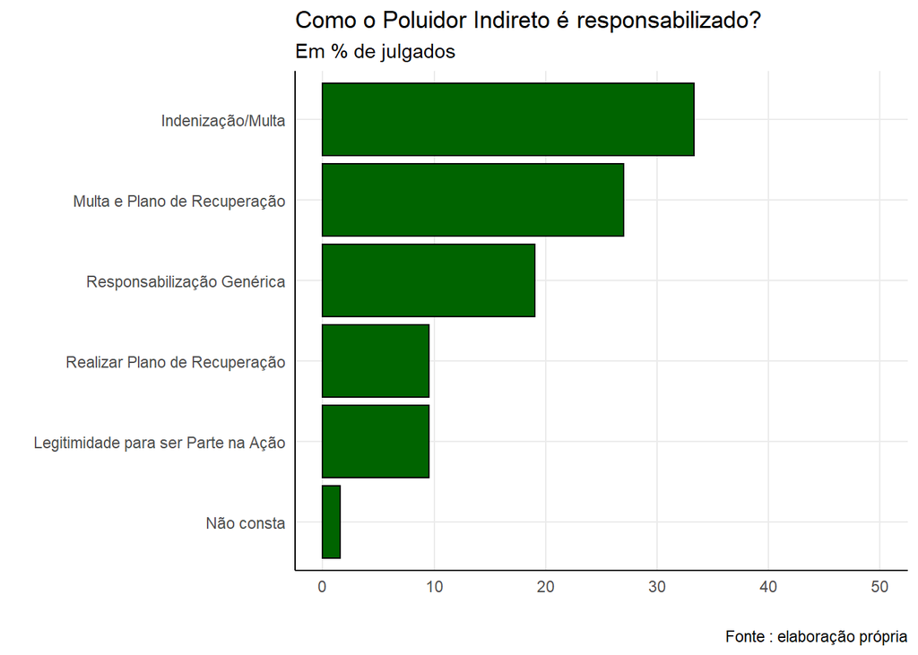

## Árvore de doutrina citada

Bolas representam **doutrinadores citados** em decisões e as linhas, o número de processos em que esses doutrinadores aparecem juntos na argumentação. Note que:

- Quanto maior a bola, maior é o numero de processos em que o doutrinador é citado;
- Quanto mais espessa a linha que conecta dois doutrinadores, maior a quantidade de processos em que eles aparecem juntos.

[interactive chart not shown]

# Árvore de precedentes citados

Bolas representam **precedentes citados** em decisões e as linhas, o número de processos em que esses precedentes aparecem juntos na argumentação. Note que:

- Quanto maior a bola, maior é o numero de processos em que o precedente é citado;
- Quanto mais espessa a linha que conecta dois precedentes, maior a quantidade de processos em que eles aparecem juntos.

[interactive chart not shown]